# Team Anonymous Proposal - Pokemon Combats Prediction

# Team Member:

Boyu Liu, Tianyi Li, Xinyue Xing, Yingjie Gao, Yingxi Huang

# Project Overview

Pokémon, originally a TV series, has been developed into games, video games, movies, and related merchandise. Pokémon are creatures of all shapes and sizes in the wild or raised by trainers. In many Pokémon games, the player is a trainer who catches Pokémon, trains them, and battles against other trainers’ Pokémon. Inspired by the worldwide popularity of Pokemon, group Anonymous plans to further investigate the operation of Pokemon Universe. For now, we are mainly curious about the following questions:

1. Does the first actor in combat have an advantage (better chance of winning)?
2. What is the best strategy to pick Pokemons for bringing to combat?
3. What are the most prominent factors influencing the winning probabilities of a Pokemon?
4. Can we predict the results of future combats

We derive the dataset on Kaggle and plan to use Machine Learning techniques such as cross-validation, decision tree regression, random forest, and principal component analysis.

# Data Description

We obtained two data files from Kaggle (https://www.kaggle.com/terminus7/pokemon-challenge?select=pokemon.csv): Pokemon characteristics and information about previous combats.

In the first data file, there are 800 distinct Pokémons and their corresponding features as listed below.

`1st type` = Primary type

`2nd type` = Secondary type

`Hit Points` = Value that determines how much damage a Pokémon can receive

`Attack` = Value of attack that a Pokémon can cause

`Defense` = Value of damage that a Pokémon takes under an attack

`Special Attack`= Base Stat that determines the special power of your Pokemon

`Special Defense` = Base Stat that determines how much damage a Pokemon can resist from Special Attacks

`Speed` = Base Stat that determines the place a Pokemon will strike in Battle.

The second data file contains 50,000 rows. Each row consists of the first and the second Pokemon in the combat as well as which one wins.

# Exploratory Data Analysis

**Data cleaning**

```r
pokemon <- read.csv("pokemon.csv")
names(pokemon)[1] <- "Pokemon_ID"
combat <- read.csv("combats.csv")
```

```r
combatm <- cbind(combat) %>%
    left_join(pokemon,
              by = c("First_pokemon" = "Pokemon_ID")) %>%
    left_join(pokemon,
              by = c("Second_pokemon" = "Pokemon_ID"))
```

suffix x for first pokemon and suffix y for second pokemon.

```r
combatm$Result[combatm$Winner == combatm$First_pokemon] <- 'Win'
combatm$Result[combatm$Winner == combatm$Second_pokemon] <- 'Loss'
combatm$Result <- as.factor(combatm$Result)
combatm$binaryResult[combatm$Result == "Win"] <- 1
combatm$binaryResult[combatm$Result == "Loss"] <- 0
```

**1. What’s the distribution of types in first and second pokemons?**

```r
Type.1.x<-c("Dragon","Steel","Flying","Psychic","Rock" ,"Fire","Electric" ,"Dark","Ghost" ,"Ground","Ice", "Water","Grass","Fighting", "Fairy" ,"Poison","Normal","Bug")

color<-c("#6F35FC","#B7B7CE","#A98FF3","#F95587","#B6A136","#EE8130","#F7D02C","#705746","#735797","#E2BF65","#96D9D6","#6390F0","#7AC74C","#C22E28","#D685AD","#A33EA1","#A8A77A","#A6B91A")

Type.1.y<-c("Dragon","Steel","Flying","Psychic","Rock" ,"Fire","Electric" ,"Dark","Ghost" ,"Ground","Ice", "Water","Grass","Fighting", "Fairy" ,"Poison","Normal","Bug")

COL1<-data.frame(Type.1.x,color)

COL2<-data.frame(Type.1.y,color)
```

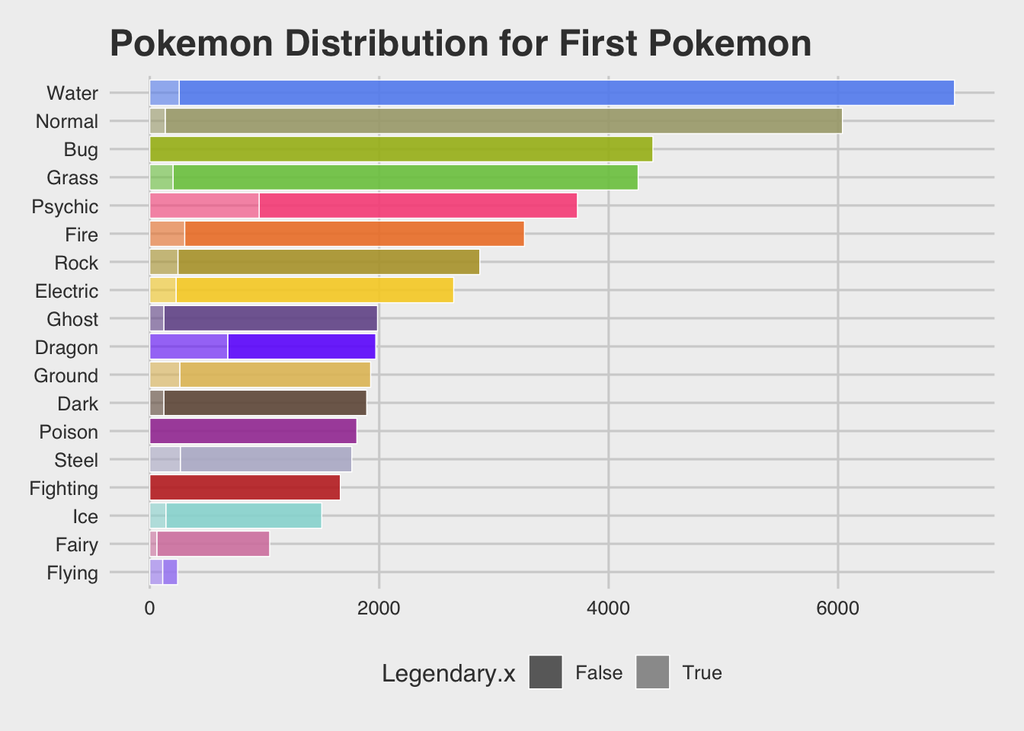

```r
merge(
  merge(combatm %>% group_by(Type.1.x) %>% summarize(tot1=n()),
        combatm %>% group_by(Type.1.x,Legendary.x) %>% summarize(count1=n()),by='Type.1.x'),
  COL1, by='Type.1.x') %>%
  ggplot(aes(x=reorder(Type.1.x, tot1),y=count1)) +
  geom_bar(aes(fill=color,alpha=Legendary.x),color='white',size=.25,stat='identity') +
  scale_fill_identity() + coord_flip() + theme_fivethirtyeight() +
  ggtitle("Pokemon Distribution for First Pokemon") + scale_alpha_discrete(range=c(.9,.6))
```

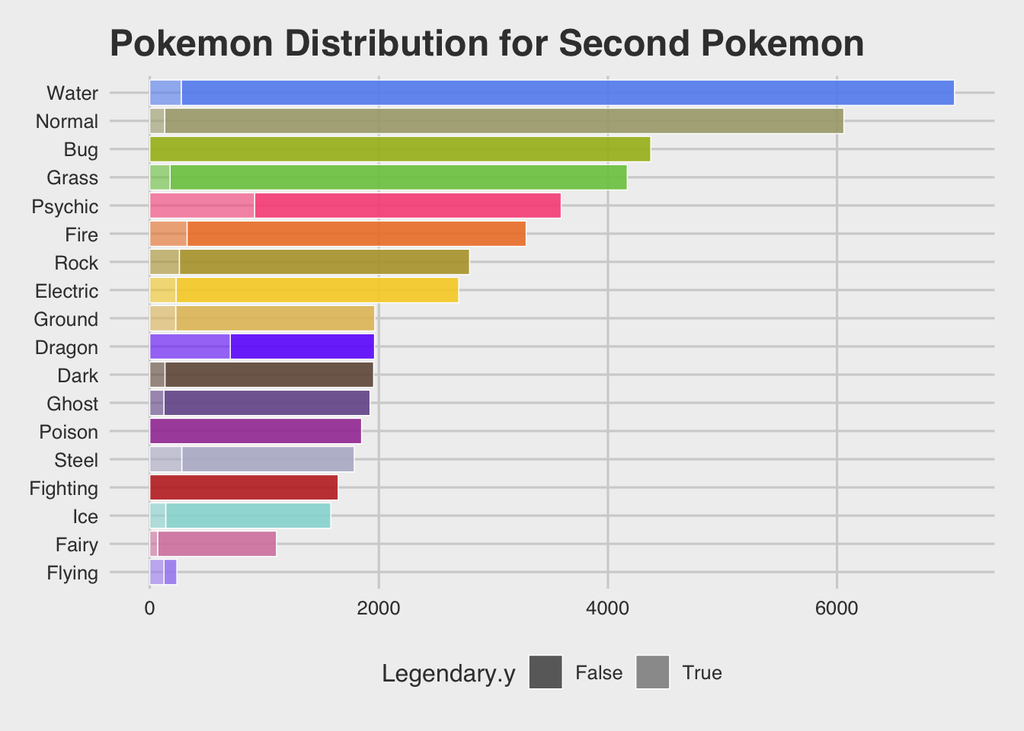

```r
merge(
  merge(combatm %>% group_by(Type.1.y) %>% summarize(tot2=n()),
        combatm %>% group_by(Type.1.y,Legendary.y) %>% summarize(count2=n()),by='Type.1.y'),
  COL2, by='Type.1.y') %>%
  ggplot(aes(x=reorder(Type.1.y, tot2),y=count2)) +
  geom_bar(aes(fill=color,alpha=Legendary.y),color='white',size=.25,stat='identity') +
  scale_fill_identity() + coord_flip() + theme_fivethirtyeight() +
  ggtitle("Pokemon Distribution for Second Pokemon") + scale_alpha_discrete(range=c(.9,.6))
```

**2. How does attack affect result?**

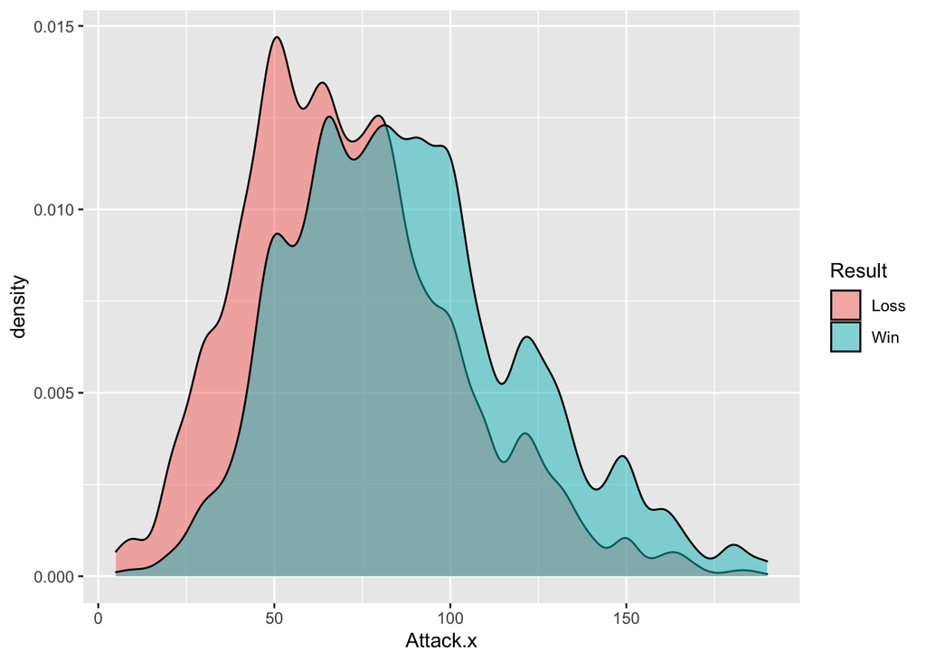

```r
ggplot(combatm, aes(Attack.x, fill = Result)) + geom_density(alpha = 0.5)
```

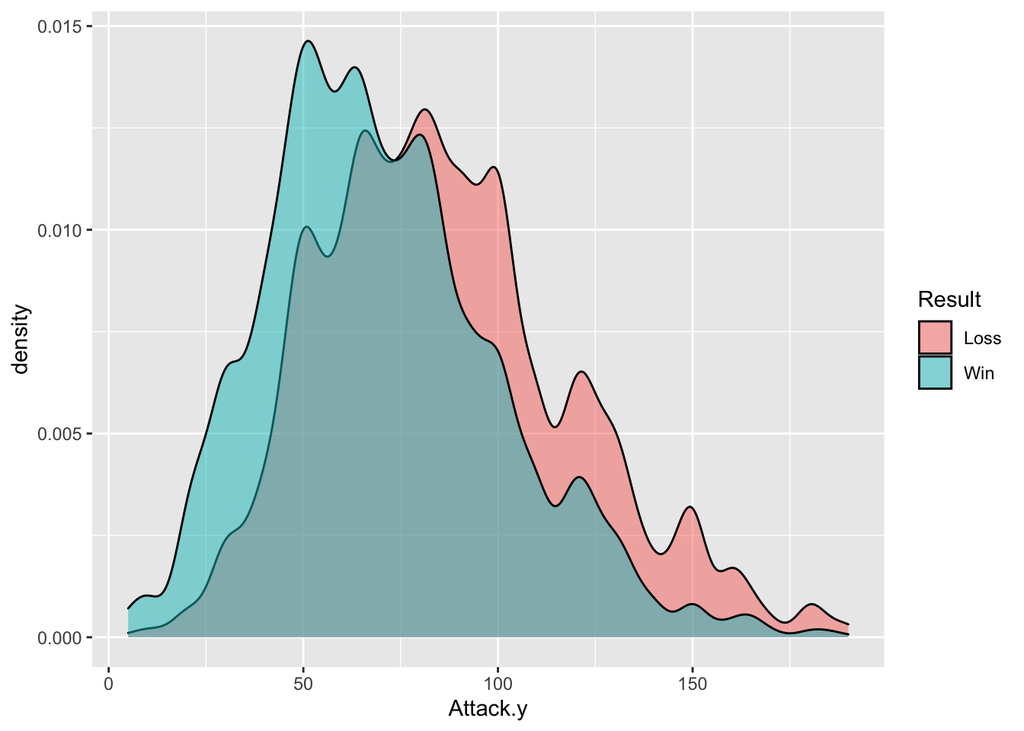

```r
ggplot(combatm, aes(Attack.y, fill = Result)) + geom_density(alpha = 0.5)
```

From the plot we can derive that the pokemon who moves first with higher attack has higher probability of winning, while the second mover with inverse scenario.

**3. How does speed difference impact win rate of pokemon?**

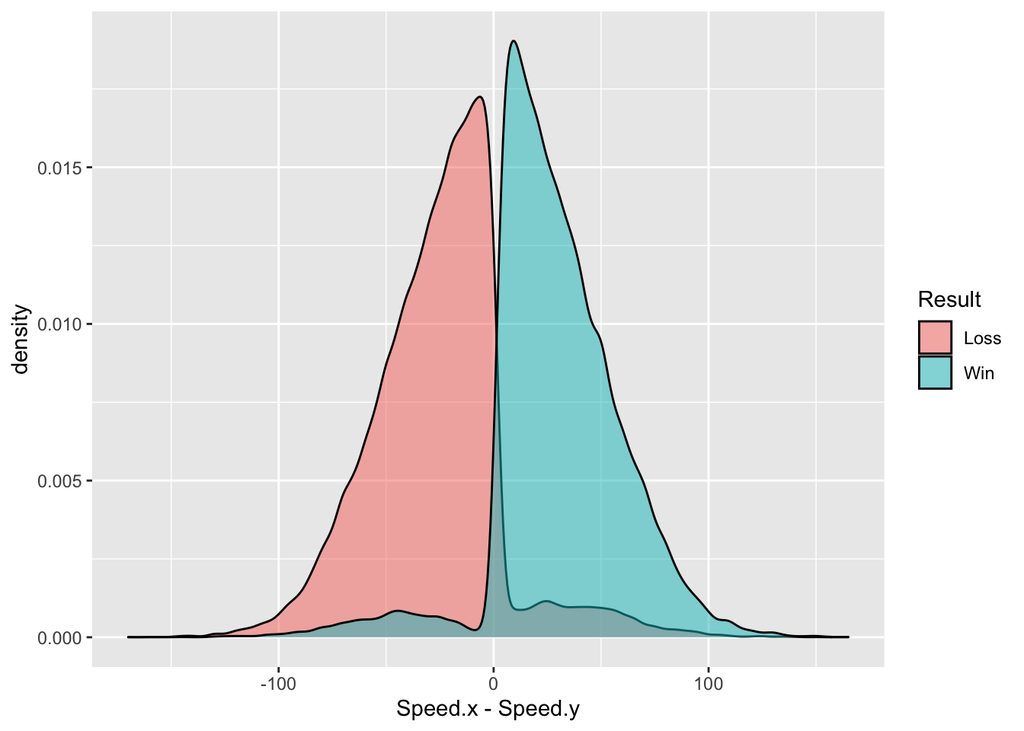

```r
ggplot(combatm, aes(Speed.x-Speed.y, fill = Result)) + geom_density(alpha = 0.5)
```

It turns out speed difference is a significant predictor with a clear threshold.

**4. What’s the correlation of result to each numerical variable?**

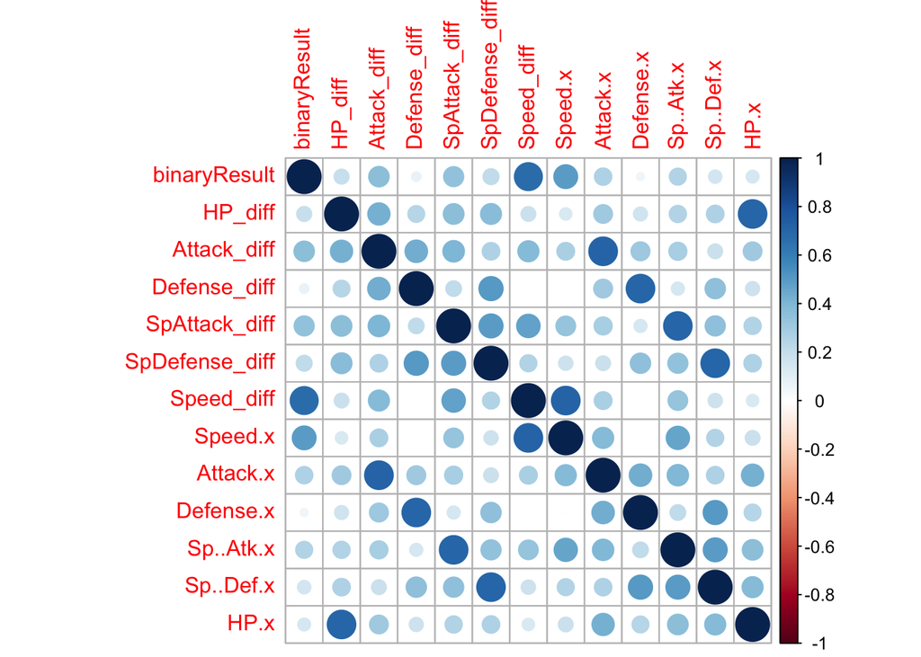

```r
combatm$HP_diff = combatm$HP.x - combatm$HP.y
combatm$Attack_diff = combatm$Attack.x - combatm$Attack.y
combatm$Defense_diff = combatm$Defense.x - combatm$Defense.y
combatm$SpAttack_diff = combatm$Sp..Atk.x - combatm$Sp..Atk.y
combatm$SpDefense_diff = combatm$Sp..Def.x - combatm$Sp..Def.y
combatm$Speed_diff = combatm$Speed.x - combatm$Speed.y


numeric_metrics <- combatm[ ,c('binaryResult',
                                'HP_diff', 'Attack_diff', 'Defense_diff',
                                'SpAttack_diff', 'SpDefense_diff', 'Speed_diff',
                                'Speed.x', 'Attack.x', 'Defense.x', 'Sp..Atk.x', 'Sp..Def.x', 'HP.x')]
cor_matrix <- cor(numeric_metrics)
corrplot(cor_matrix,method = "circle")
```

# Data Analysis Plan

In order to address the questions we put forward in the project overview, the primary problem we need to deal with is to construct a model to predict the combat results, with whether the first pokemon would win as the binary response variable, and probably the differences in each feature between the two pokemons as the predictors. The algorithms we plan to employ for constructing the model include logistic regression, k-Nearest Neighbors, Support Vector Machine, Naive Bayes, and Decision Trees.